# LOWESS Normalization Demo

Mikhail Dozmorov

2025-09-24

## 0.1 Introduction

In RNA-seq (and originally microarrays), **intensity-dependent bias** can occur, where the log-ratio of expression values (`M`) depends on the average intensity (`A`).

This creates a curvature in the **MA plot**.

We can remove such bias using **parametric regression** or more commonly **LOWESS normalization**.

## 0.2 Simulate RNA-seq MA data with bias

```r
set.seed(123)

# Simulate average expression (A values, log2 scale ~ 3–16 typical range)
x <- runif(50, 0, 16)

# Simulate M values (log fold-changes), with nonlinear bias + random noise
y <- 1 + 0.5 * exp(-0.5 * x) + rnorm(50, 0, 0.1)

# Organize into data frame
data <- data.frame(A = x, M = y)
data <- data[order(data$A), ]

head(data)
```

```
##            A        M
## 35 0.3938190 1.432227
## 18 0.6729525 1.230602
## 6  0.7289040 1.389935
## 15 1.6467949 1.181422
## 46 2.2208970 1.115602
## 41 2.2848004 1.189879
```

## 0.3 Visualize the biased MA plot

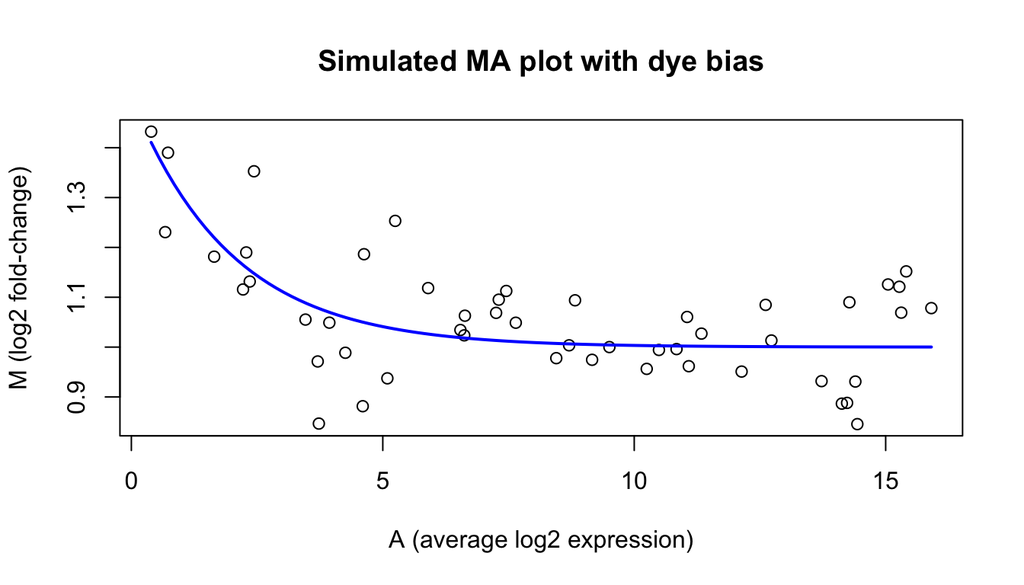

```r
plot(data$A, data$M,
     main = "Simulated MA plot with dye bias",
     xlab = "A (average log2 expression)",
     ylab = "M (log2 fold-change)")
curve(1 + 0.5*exp(-0.5*x), add = TRUE, col = "blue", lwd = 2)
```

The curve shows the **systematic non-linear bias** added to the simulated data.

## 0.4 Parametric nonlinear fit

In real data, we usually don’t know the exact functional form of the bias. Here, we attempt to **recover the curve** using **nonlinear least squares (NLS)**.

```r
# Fit a parametric exponential decay model
fit <- nls(M ~ a + b * exp(-c * A),
           data = data,
           start = list(a = 1, b = 1, c = 1))

summary(fit)
```

```
##
## Formula: M ~ a + b * exp(-c * A)
##
## Parameters:
##   Estimate Std. Error t value Pr(>|t|)
## a  1.01708    0.01757  57.896  < 2e-16 ***
## b  0.48989    0.10449   4.688 2.39e-05 ***
## c  0.60544    0.19126   3.166  0.00272 **
## ---
## Signif. codes:  0 '***' 0.001 '**' 0.01 '*' 0.05 '.' 0.1 ' ' 1
##
## Residual standard error: 0.09482 on 47 degrees of freedom
##
## Number of iterations to convergence: 4
## Achieved convergence tolerance: 4.028e-07
```

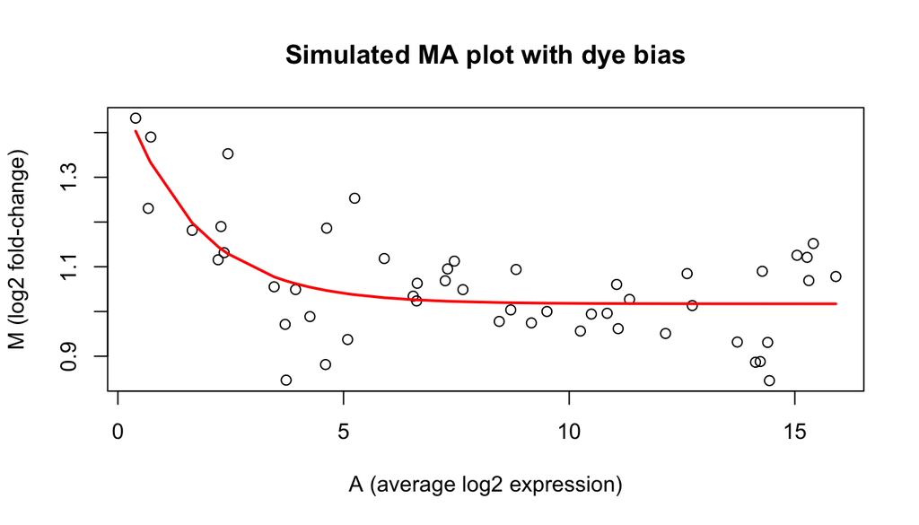

```r
plot(data$A, data$M,
     main = "Simulated MA plot with dye bias",
     xlab = "A (average log2 expression)",
     ylab = "M (log2 fold-change)")
# Add fitted curve
lines(data$A, predict(fit), col = "red", lwd = 2)
```

## 0.5 Bias correction

We subtract the fitted curve from the observed M values to remove the intensity-dependent bias.

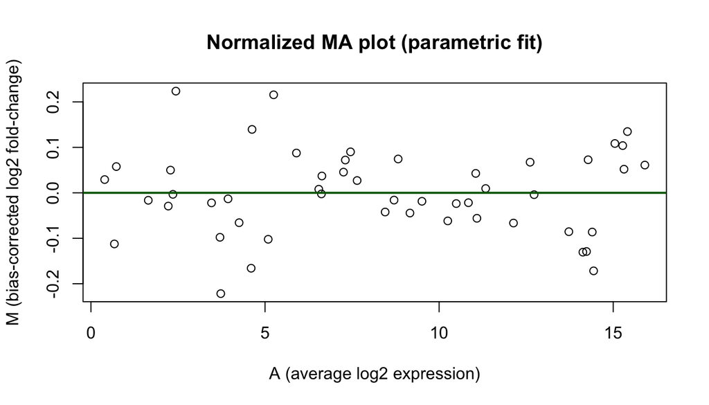

```r
# Corrected M values
M.norm <- data$M - predict(fit)

plot(data$A, M.norm,
     main = "Normalized MA plot (parametric fit)",
     xlab = "A (average log2 expression)",
     ylab = "M (bias-corrected log2 fold-change)")
abline(h = 0, col = "darkgreen", lwd = 2)
```

Now, the corrected values are **centered around zero**, as expected if most genes are **not differentially expressed**.

## 0.6 Why LOWESS instead of a parametric model?

- Parametric models require specifying a functional form.
- In practice, RNA-seq biases are not known in advance.
- **LOWESS (Locally Weighted Scatterplot Smoothing)** provides a flexible, **non-parametric fit** to remove systematic curvature in MA plots.
- Implemented in many normalization tools (e.g., `limma`, cyclic loess).

# 1 Understanding LOESS Smoothing Step by Step

## 1.1 Introduction

LOESS (**Locally Estimated Scatterplot Smoothing**) is a **non-parametric regression** method.  
It works by:  
- Selecting a **local neighborhood** of points around the target.  
- Assigning **weights** (closer points get higher weight).  
- Fitting a **weighted linear regression**.  
- Repeating for each point of interest.

Here we illustrate the procedure “by hand” using the `wine` dataset.

## 1.2 Load data

```r
# install.packages("HDclassif") # if not already installed
library(HDclassif)

# Load wine dataset
data(wine)

# Rename some variables for clarity
colnames(wine)[colnames(wine) == "V1"] <- "Alcohol"
colnames(wine)[colnames(wine) == "V10"] <- "Color"

head(wine[, c("Alcohol", "Color")])
```

```
##   Alcohol Color
## 1   14.23  5.64
## 2   13.20  4.38
## 3   13.16  5.68
## 4   14.37  7.80
## 5   13.24  4.32
## 6   14.20  6.75
```

## 1.3 Step 1: Pick a target observation

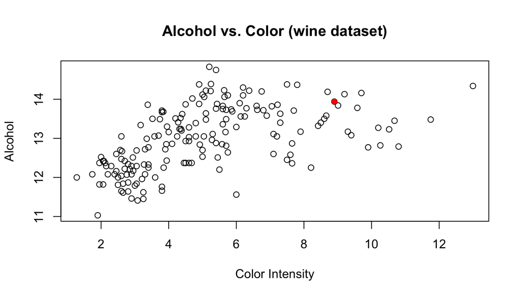

```r
attach(wine)

plot(Color, Alcohol,
     main = "Alcohol vs. Color (wine dataset)",
     xlab = "Color Intensity",
     ylab = "Alcohol")

# Pick observation 50
points(Color[50], Alcohol[50], pch=16, col="red")
```

```r
Color[50]   # x value
```

```
## [1] 8.9
```

```r
Alcohol[50] # y value
```

```
## [1] 13.94
```

## 1.4 Step 2: Compute distances

We compute distances along the **x-axis (Color)** to all other points.

```r
distance <- abs(Color - Color[50])
head(distance)
```

```
## [1] 3.26 4.52 3.22 1.10 4.58 2.15
```

## 1.5 Step 3: Define neighborhood

Let’s choose the **50 nearest neighbors**.

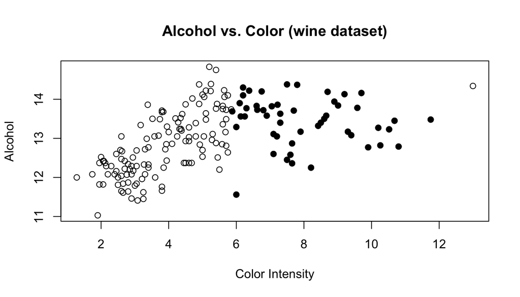

```r
neighbor <- ifelse(rank(distance) <= 50, 1, 0)

plot(Color, Alcohol,
     main = "Alcohol vs. Color (wine dataset)",
     xlab = "Color Intensity",
     ylab = "Alcohol")
# Plot neighbors
points(Color[neighbor == 1], Alcohol[neighbor == 1], pch = 19)
```

## 1.6 Step 4: Scale distances and compute weights

Weights are assigned using the **tricube kernel**:

$$w_i = \begin{cases}
(1 - u_i^3)^3, & 0 \le u_i < 1 \\
0, & \text{otherwise}
\end{cases}$$

where $u_i = \frac{\text{distance to target}}{\text{max distance in neighborhood}}$.

```r
delta.50 <- max(distance[neighbor == 1])
u <- ifelse(neighbor == 1, distance / delta.50, NA)

weight <- ifelse(u >= 0 & u < 1, (1 - u^3)^3, 0)

# Combine into table
combined_data <- data.frame(distance, neighbor, u, weight)
combined_data[45:55, ]
```

```
##    distance neighbor         u      weight
## 45     3.86        0        NA          NA
## 46     3.66        0        NA          NA
## 47     4.00        0        NA          NA
## 48     2.80        1 0.9271523 0.008366574
## 49     2.70        1 0.8940397 0.023243736
## 50     0.00        1 0.0000000 1.000000000
## 51     1.70        1 0.5629139 0.554659147
## 52     3.30        0        NA          NA
## 53     1.85        1 0.6125828 0.456752912
## 54     2.60        1 0.8609272 0.047392581
## 55     3.05        0        NA          NA
```

## 1.7 Step 5: Weighted regression

We fit a **local weighted linear regression** around observation 50.

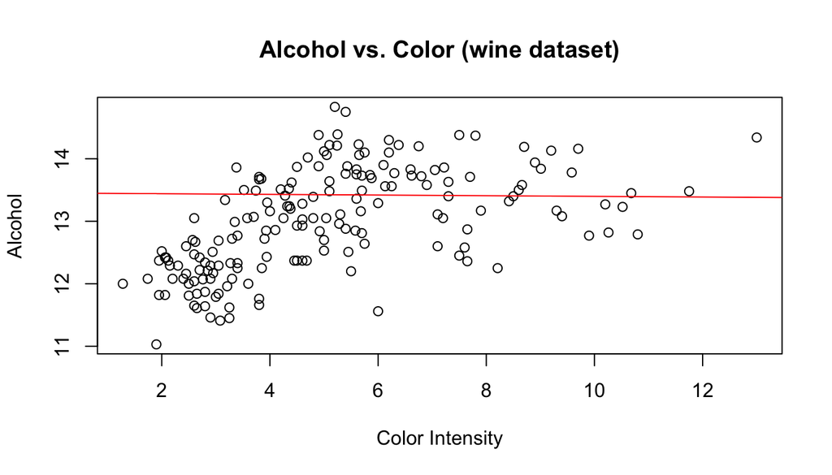

```r
plot(Color, Alcohol,
     main = "Alcohol vs. Color (wine dataset)",
     xlab = "Color Intensity",
     ylab = "Alcohol")

local.50 <- lm(Alcohol ~ Color, weights = weight)
abline(local.50, col="red")
```

## 1.8 Step 6: Repeat for another observation

Let’s repeat for observation 30.

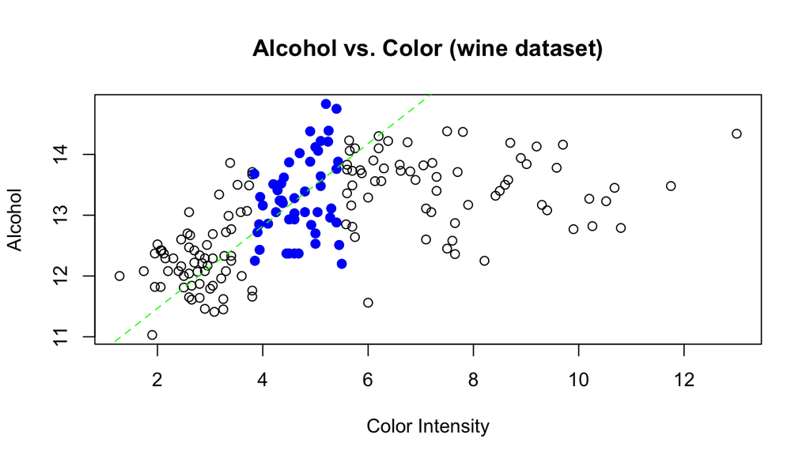

```r
plot(Color, Alcohol,
     main = "Alcohol vs. Color (wine dataset)",
     xlab = "Color Intensity",
     ylab = "Alcohol")
# Mark observation 30
points(Color[30], Alcohol[30], pch=16, col="green")

# Distances
distance.30 <- abs(Color - Color[30])
neighbor.30 <- ifelse(rank(distance.30) <= 50, 1, 0)

# Plot neighbors
points(Color[neighbor.30 == 1], Alcohol[neighbor.30 == 1], pch = 19, col="blue")

# Compute weights
delta.30 <- max(distance.30[neighbor.30 == 1])
u.30 <- ifelse(neighbor.30 == 1, distance.30 / delta.30, NA)
weight.30 <- ifelse(u.30 >= 0 & u.30 < 1, (1 - u.30^3)^3, 0)

# Local regression
local.30 <- lm(Alcohol ~ Color, weights = weight.30)
abline(local.30, lty=2, col="green")
```

## 1.9 Step 7: Built-in LOESS

Of course, we usually use the built-in `loess()` function rather than computing by hand.

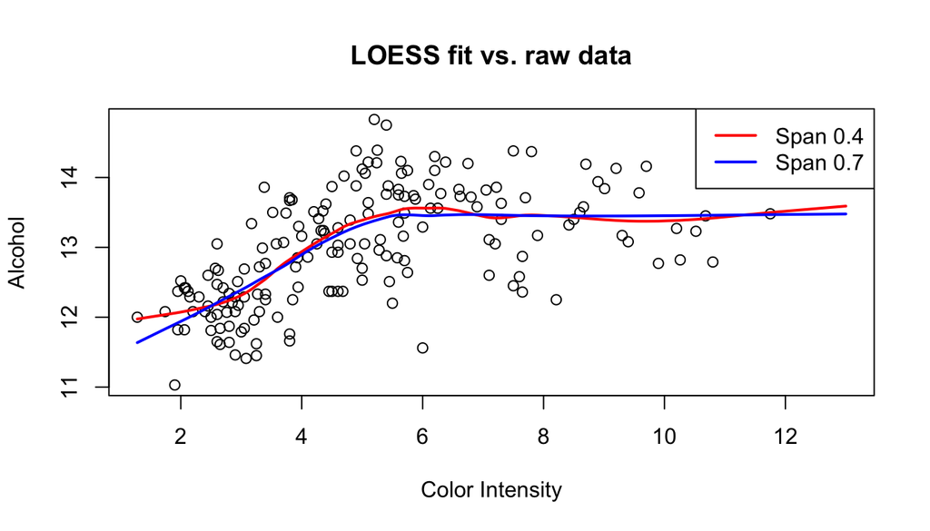

```r
out <- loess(Alcohol ~ Color, data = wine, span = 0.4, degree = 1)

# Plot original data
plot(Color, Alcohol, main="LOESS fit vs. raw data",
     xlab="Color Intensity", ylab="Alcohol")

# Add LOESS smoothed line
lines(sort(out$x), out$fitted[order(out$x)], col="red", lwd=2)

# Try larger span (smoother curve)
out2 <- loess(Alcohol ~ Color, data = wine, span = 0.7, degree = 1)
lines(sort(out2$x), out2$fitted[order(out2$x)], col="blue", lwd=2)
legend("topright", legend=c("Span 0.4","Span 0.7"),
       col=c("red","blue"), lwd=2)
```

## 1.10 Summary

- LOESS is a **non-parametric regression** that fits weighted linear regressions in local neighborhoods.
- We manually computed distances, neighbors, and weights to see how it works.
- The built-in `loess()` function automates this process, with the `span` parameter controlling smoothness.